# Data Exploration of Dark Chocolate Bars from the World Chocolate Industry

## by Marina Atlija

## Investigation Overview

Who does not like chocolate?

It is one of the most popular sweets in the world. However, here we will investigate the Dark Chocolate bars dataset, which is a distinctly adult treat.

Dark Chocolate is healthy, complex and has a touch of bitterness which is preferable by some people.

The emphasis is placed on the optimal number of ingredients in the chocolate bar and association with other variables in the dataset.

We will explore the dataset by using different plots (histograms, scatterplots, bar, heatmap, and line plots).

## Dataset Overview

> Dataset was taken from the Kaggle: https://www.kaggle.com/soroushghaderi/chocolate-bar-2020?select=chocolate.csv

> It contains expert ratings of 2224 individual chocolate bars from 2006 to 2020 year from 62 countries of bean origin.

> This dataset has a total of 20 columns:
> - ref, company, company_location, review_date, country_of_bean_origin, specific_bean_origin_or_bar_name, cocoa_percent, rating, counts_of_ingredients, beans, cocoa_butter, vanilla, lecithin, salt, sugar, sweetener_without_sugar, first_taste, second_taste, third_taste, fourth_taste

## Histograms and scaterplots between four variables

> Here I used the seaborn.pairplot to show the distribution of four variables: Rating, Cocoa %, Number of Ingredients, and Review Date. On diagonal line we can see histograms of each variable.
> - Rating - mostly all points are between 2.5 and 4, while there are a few points below 2.5, and there are non-points above 4.
> - Cocoa % - mostly all data points are concentrated between 60 and 75 %, and data are close by a normal distribution
> - Number of Ingredients - there are six groups were group 2 and 3 most prevalent
> - Review Date - we can see the rise of chocolate samples from beginning till 2015, after that we can observe a small fall and afterward the number of tested chocolate bars stagnates

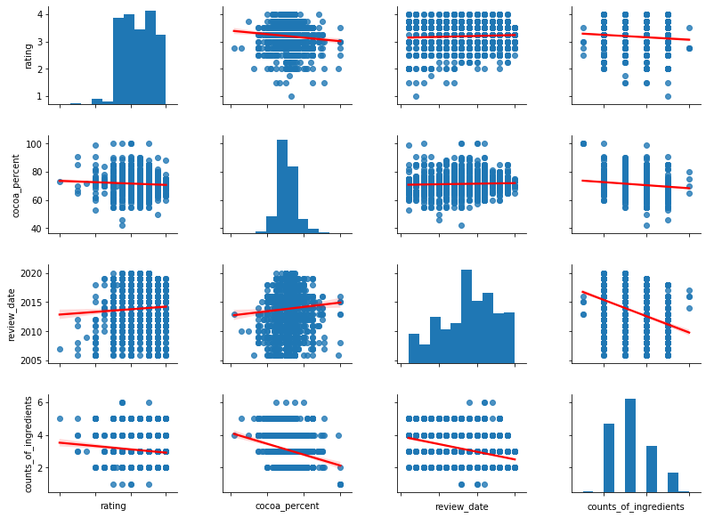

```python
dataset_hist = df[['ref','company', 'company_location','country_of_bean_origin','specific_bean_origin_or_bar_name', 'counts_of_ingredients', 'rating', 'cocoa_percent', 'review_date', 'index_id']]
dataset_hist_2 = dataset_hist.drop_duplicates()

plots = sb.pairplot(dataset_hist_2[['rating', 'cocoa_percent', 'review_date','counts_of_ingredients']],
                   size=1.5, diag_kind='auto',  kind="reg", plot_kws={'line_kws':{'color':'red'}});

plots.set(xticklabels=[]);
plots.fig.set_size_inches(11.69, 8.27)
```

## Associations between variables - shown by the heatmap

Associations between four variables:

> - taken into account the above plot and the heat map we can observe low and moderate correlations between variables.
> - There is a clear trend of negative correlation between counts_of_ingredients variable with other three variables, whereas the strongest association is between counts_of_ingredients and review_date (which clearly shows that companies tend to have chocolates bar with fewer ingredients.
> - a negative correlation between cocoa % and counts_of_ingredients is expected, more ingredients result in reduced content of cocoa in chocolate bars
> - another small negative correlation (between rating and counts_of_ingredients) is showing that chocolate bars with more ingredients tend to have lower ratings than chocolate bars with fewer ingredients

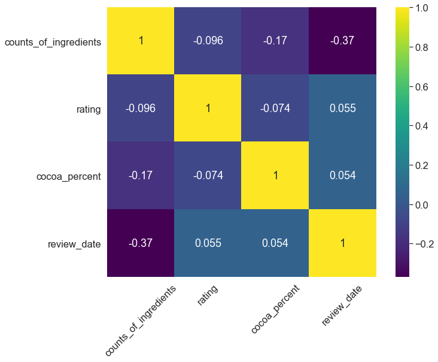

```python
data_hm = df[['counts_of_ingredients','rating', 'cocoa_percent', 'review_date']]

#delete group 1 and 6 - since we have only a few values in these two groups
data_hm = data_hm[data_hm['counts_of_ingredients'].isin([2,3,4,5])]
#heatmap plot - which shows correlations between chosen four variables
colormap = plt.cm.viridis
plt.figure(figsize=(11.69, 8.27))
sb.set(font_scale=1.5)
heat_map = sb.heatmap(data_hm.corr(), square=True, cmap=colormap, annot=True);
heat_map.set_xticklabels(heat_map.get_yticklabels(), rotation=45)
plt.show();
```

## A total number of ingredients in chocolate bar sample

- There is a total of seven ingredients that are used to make the reviewed chocolate bars. Cocoa beans is present in all chocolates, as it is expected to be. Then follows sugar, cocoa butter, lecithin, vanilla, sweetener_without_sugar and salt.

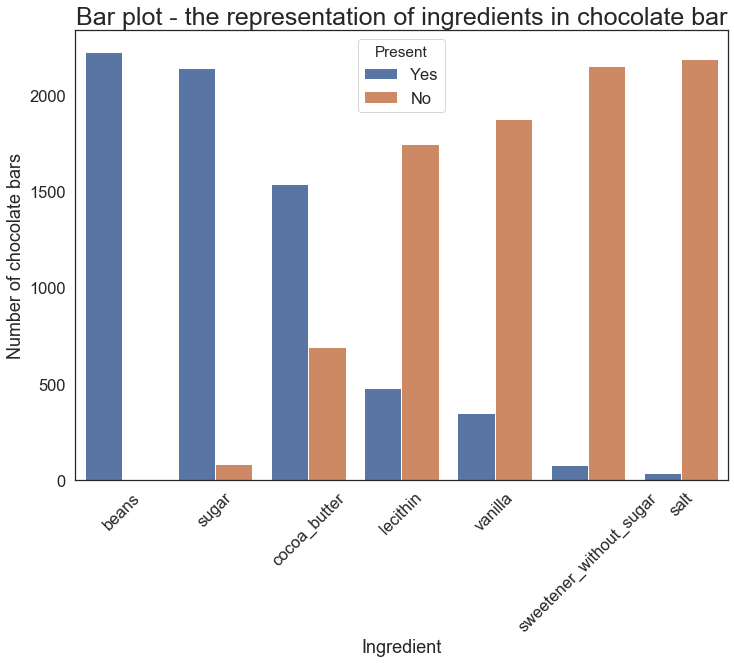

```python
ingredients = df[['index_id','Ingredient','Present']]
ingredients = ingredients.drop_duplicates()
#group by ingredient and by presence
g_ingredients = ingredients.groupby('Ingredient',)['Present'].value_counts().reset_index(name='count')

with sb.axes_style('white'):
    ingredients = ["beans", "sugar", "cocoa_butter", "lecithin", "vanilla", "sweetener_without_sugar","salt"]
    plt.figure(figsize=(11.69, 8.27));
    ax = sb.barplot(x="Ingredient", y="count", hue="Present", data=g_ingredients,
               order=ingredients);
    ax.set_title('Bar plot - the representation of ingredients in chocolate bar', fontsize = 25)
    ax.set_xlabel('Ingredient', fontsize =18)
    ax.set_ylabel('Number of chocolate bars', fontsize =18)
    ax.set_xticklabels(ingredients, rotation= 45)
    plt.show()
```

## Bubble plot - representation of average chocolate bar rating bynumber of ingredients through the time

> From this plot we can observe that at beggining there were more choclates bar with greater number of ingredients had on average a lower rating than chocolate bars with fewer ingredients and lower number of samples tend to have a higher rating.

> through the time we can see how bubble size is widening for chocolate bars with fewer ingredients (2 and 3) while the rating does not oscillate too much

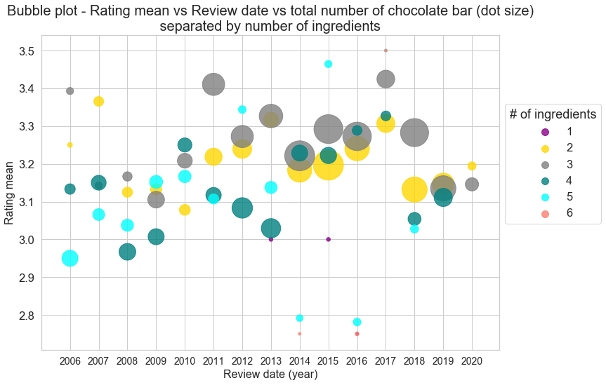

```python
dat1 = dataset_hist_2.groupby(['review_date','counts_of_ingredients'])['rating'].mean().reset_index(name='rating_mean')
dat2 = dataset_hist_2.groupby('review_date')['counts_of_ingredients'].value_counts().reset_index(name='count')

dat_count_mean = pd.merge(dat1, dat2, on=['review_date', 'counts_of_ingredients'], how='left')

# list of years which will be used for build the plot (plt.xticks)
years = list(dataset_hist_2['review_date'].drop_duplicates())
#set colors
colors = [None,"darkmagenta", "gold", "grey", "teal", "aqua", "salmon"] # colors for a line plot

with sb.axes_style('whitegrid'):
    #count = dat_count_mean['count']
    plt.figure(figsize= ( 11.69, 8.27))

    for i in range(1,7):
        df = dat_count_mean[dat_count_mean['counts_of_ingredients']== i]
        sb.regplot(x="review_date", y="rating_mean", data=df,
                   fit_reg=False, scatter_kws={"s": df['count']*15}, #to obtain bubble plot
                   color = colors[i], label = i);
    plt.title("Bubble plot - Rating mean vs Review date vs total number of chocolate bar (dot size)\n separated by number of ingredients ", fontsize=20)
    plt.ylabel("Rating mean", fontsize=16);
    plt.xlabel("Review date (year)", fontsize=16);
    #plt.legend(title = '# of ingredients',loc='upper right');

    plt.xticks(years, fontsize = 14)
    # Legend for State colours
    lgd = plt.legend(bbox_to_anchor=(1, 0.8), title="# of ingredients")
    for handle in lgd.legendHandles:
        handle.set_sizes([100.0])
```

## Conclusions

- Number of ingredients have an influence on how chocolate bar will be rated - more ingredients lower rating.
- The number of chocolates with fewer ingredients (2 or 3) were more favorable through the time.
- Hence, companies tend to produce more chocolates with fewer ingredients.